# DS 4010 Report

Marissa Baietto

05-14-2025

## Goal

The main goal for this project is to promote traffic safety awareness. This dashboard will be useful for the driving safety advocacy groups because it provides an easy way to analyze the large car crash data set for those who are not data scientists, such as grabbing summary statistics and identifying trends using pre-made visualizations. The interactivity of this dashboard will allow advocacy groups to present custom statistics and figures to educate the public and policy makers. The analysis on fatalities could also be used to educate the driving population of Iowa on the harms of poor driving habits or poor decision making on the road. My target audience for this project is the driving population of Iowa and any driving safety advocacy groups in Iowa, such as the Central Iowa Traffic Safety Task Force. They would be interested in my dashboard because they can use it to enhance their efforts to promote awareness of the inherent dangers of driving. Data Collection

There were two main datasets used for this project: “Crashes” and “Vehicle”. Both data sets were sourced from the Iowa Department of Transportation website. The “Crashes” dataset can be found here: Crash Data (SOR) | Iowa Department of Transportation - Open Data, and the “Vehicle” data set can be found here: Crash Vehicle Data (SOR) | Iowa Department of Transportation - Open Data. Both of these datasets were downloaded as csv file by clicking the “Download” button on the Iowa Department of Transportation website.

To clean the “Crashes” data, I selected only the columns I was immediately interested in, minimizing the amount of space my data set used. I then refactored any variables necessary in order to shorten the value names for easier visualization in my graphs. I was not concerned for null values in my data visualization, so I did not focus on them at this stage. In the later stage for data modeling, I handled null values cases. The process was similar for cleaning the “Vehicle” data, except that the “Vehicle” data required more cleaning. There were a lot of variables in which there were values that did not make much sense. For example, there were blood alcohol content (BAC) values that were above 0.5, and some were as high as 0.99. The lethal level is generally believed to be 0.40, so I decided to filter out any levels above that. Similarly, I fixed the driver age and speed limit variables to exclude values that were not technically possible or were extreme outliers (such as a 6-year-old driver).

The “Crashes” and “Vehicle” data were joined on the crash ID, which was unique to every crash that appeared in the “Crashes” data. This join was done using a left join, because some crashes did not have vehicle data, and I wanted to keep those crashes. If a crash had two or more vehicles involved, the “Vehicle” data had a row for each vehicle involved in the crash. As a result, for some vehicle crashes, the join resulted in multiple observations, or rows, for a single crash. At this point, I made the decision to only include one observation for each unique vehicle crash. When creating summary statistics or graphs that summarize the data, I didn’t want to inflate the statistics by having the same crash contribute their value multiple times. I selected the unique cases by selecting the first appearance of each crash.

This data had the unique challenge of being very large. The “Vehicle” and “Crash” datasets were both over 200,000 kb each. In order to upload these datasets to GitHub, I needed to use Python to split these files into chunks, with each chunk containing 50,000 rows of the original data set. Then, in my “Data Cleaning” code, I loaded in all of these chunks and used “rbind” to re-create the original data set. Once I had my final cleaned dataset, I converted it into a RDS file in R. This made dashboard deployment much faster.

## Modeling

The target variable, Crash Severity, was recoded into a binary variable, bodily harm, where crashes categorized as “Fatal,” “Major Injury,” or “Minor Injury” were assigned a value of 1 (bodily harm), and all other categories (e.g., “Property Damage Only”) were assigned 0. This variable was used as the response in my model. To handle missing data, I either replaced missing numeric values with 0, merged missing categories when appropriate, or removed rows with missing data for certain variables (such as driver age and county). Given the size of the dataset (over 600,000 rows), I randomly sampled 50,000 rows for training to optimize processing time.

```r
glm_severity <- glm(Bodily_Harm ~ ., data = sample)
```

To interpret the model, I calculated odds ratios for each variable’s effect on the likelihood of bodily harm. I filtered results to only include variables with a significant p-value (< 0.05), allowing users to clearly identify the most important predictors of bodily harm. These results are displayed on the dashboard, where text boxes highlight the change in odds relative to the baseline category for each variable.

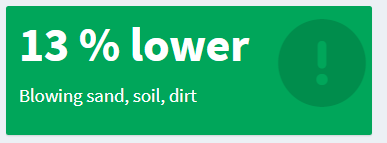

For predicting property damage, I used a linear regression model with the same explanatory variables as in the bodily harm model. The purpose of this model was to estimate the amount of property damage from a crash based on environmental and pre-crash factors, such as Weather Conditions and Driver Age. The model assumes a linear relationship between the predictors and the amount of damage. I used the following R code to build the model:

```r
model_property <- lm(Amount.of.Property.Damage ~ ., data = sample)
```

Similar to the bodily harm model, I pre-estimated the property damage model and stored it as an RData file to facilitate faster predictions on the dashboard. Users can input values for each variable, and the model predicts the amount of property damage resulting from the crash. This interaction allows users to see the impact of different factors on property damage in real-time.

## Dashboard

The dashboard consists of three main tabs: Information, Graphics, and Model. The Information tab provides a summary of the dashboard’s goals and organization. I chose to place this tab first to help users understand how to navigate the dashboard before they start exploring the data.

The Graphics tab contains four sub-tabs: Overall Trends, When Crashes Occurred, Where Crashes Occurred, and Driver Characteristics.

Overall Trends provides an overview of the total number of crashes, fatalities, injuries, property damage, and other key statistics for the user-selected time range. It includes a time-series graph that compares the total number of crashes per year for the selected period. Below the graph, text boxes display aggregate statistics such as the total number of crashes, people involved, vehicles involved, property damage, fatalities, major injuries, and minor injuries. These summaries allow users to quickly understand the scale of the issue and examine trends over time.

When Crashes Occurred shows bar charts detailing the number of crashes by month, day of the month, day of the week, and hour of the day. The monthly bar chart is interactive, allowing users to click on a month to view daily crash data. This feature helps users pinpoint specific timeframes with higher crash frequencies. This tab highlights when crashes are most likely to occur and offers insight into potential factors, such as time of day or seasonality.

Where Crashes Occurred displays a map of Iowa, color-coded by the total number of crashes per county using a log scale (from blue for the least crashes to red for the most). The user can click on any county to see the exact locations of crashes within that county. This tab provides valuable insight into geographic crash hotspots, helping users understand which areas have the highest crash rates.

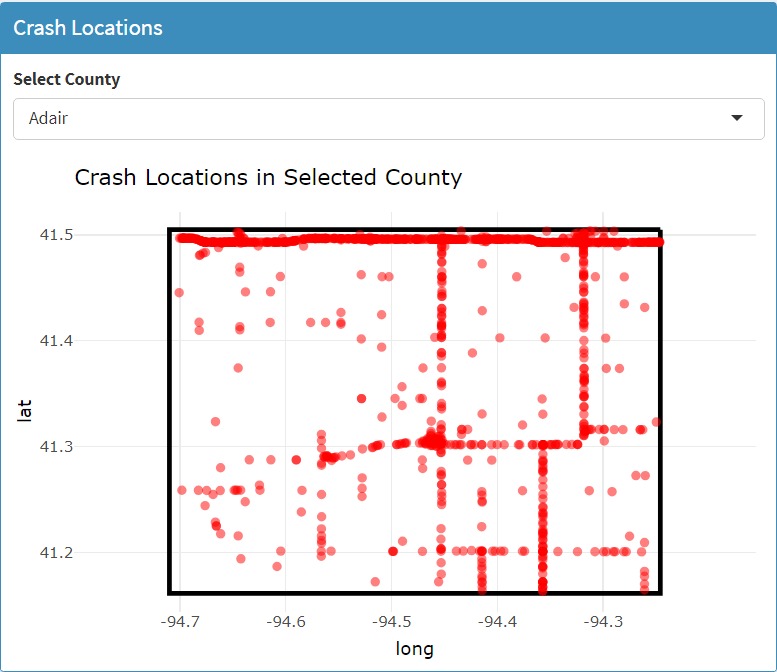

Map graphics in the “Where Crashes Occured” tab

Driver Characteristics includes bar charts that show the total number of crashes by driver age and gender. This tab provides a demographic breakdown of crashes and reveals patterns related to driver characteristics.

The Model tab contains two models:

1. Bodily Harm Model: This section shows the relationship between pre-crash factors and the odds of bodily harm resulting from a crash. The page is organized into subheadings for each variable in the model, with text boxes displaying how the odds of bodily harm change between the base category and other values. For example, for drug results, the text box indicates that the odds of bodily harm are 17% higher when alcohol is present in the crash. Text boxes are color-coded: red for categories with a 20% or more increase in odds, yellow for 1-19%, and green for a decrease in odds.
2. Property Damage Model: This section allows users to input values for crash characteristics (using text boxes for numeric variables and dropdowns for categorical variables) to predict the expected amount of property damage from the crash. When the user clicks the “predict button,” the dashboard shows the predicted property damage amount, giving users a better understanding of the relationship between crash factors and property damage.

The dashboard was built using R Shiny, Shiny Dashboard, and Plotly for interactivity. R Shiny provided the framework for building the dashboard’s structure and interactivity, while Plotly allowed me to create interactive graphics that respond to user inputs.

For example, users can hover over the bars or parts of the map to see the exact values of categories.

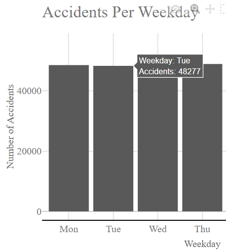

Example of text when mouse hovers over graph

I also used Plotly to create a dynamic “day plot” that updates based on the user’s month selection, allowing for a more detailed exploration of daily trends.

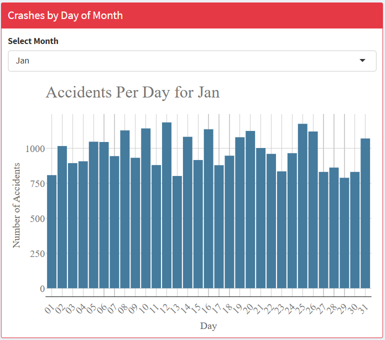

Interactive Plotly graphics in the “When Crashes Occured” tab

While creating the dashboard was straightforward, I encountered challenges with publishing due to the large data file size. Despite converting CSV files to RDS format, the dashboard still took a long time to publish. Additionally, the graphics initially took 10-20 seconds to load, and I experienced issues with the dashboard disconnecting from the server. After troubleshooting, I discovered that having too many Plotly graphs on a single page caused the issue. By splitting the graphs across multiple tabs, I was able to resolve the problem and ensure that the dashboard functions smoothly.

## Learning

One of the aspects I was most interested in was understanding what makes a crash fatal. Based on public service announcements, social media, and driver’s education materials, I had the impression that fatal crashes were common. However, that turned out to be false—only about 2% of crashes in this dataset were fatal. On the other hand, injuries were very common. I was also surprised by the amount of property damage caused by crashes. From 2015 to 2020, the average property damage per crash was $6,649. While many crashes resulted in no damage and some extreme outliers skewed the average, this is still a significant figure.

It wasn’t surprising that Des Moines had the highest number of crashes in the state, but I was struck by how extreme the difference was. I had to apply a log scale to the map in order to make differences among other regions visible—otherwise, the visualization was almost entirely blue or red with no gradient in between. It was also interesting to see that major roads were visible in the county-level plots based on where crashes occurred.

Another notable finding was that crash counts by driver age peaked at 18, declined with age, then showed another smaller peak in the 50s before decreasing again.

The linear model predicting property damage, however, was less informative. The R-squared value was only 0.04, indicating a very weak model fit. The intercept was around $4,000, meaning that even under the safest conditions—daylight, clear weather, and dry roads—the expected property damage from a crash was still around $4,000.

## Discussion

This project analyzed car crash data from Iowa spanning 2014 to 2024. It examined both the factors leading to crashes and the severity of their outcomes, as well as aggregate statistics such as the number of crashes and the resulting property damage. The data was cleaned and processed using R, and the dashboard was developed using R Shiny.

If I had more time, I would expand the Graphics tab to explore additional crash-related factors. There were many interesting variables I did not have time to fully analyze, such as work zone status, blood alcohol levels, and the recorded cause of each crash. The “cause of crash” variable alone included over 74 unique values, making it particularly complex to clean and summarize. I also would have liked to improve the property damage model—potentially by restricting the analysis to crashes that resulted in damage or by using a different modeling approach besides least squares regression.

The dataset was quite large, with over 600,000 rows and more than 40 variables, which posed challenges in terms of cleaning and analysis given the limited time and computing resources.

The code for this project is available in the “Code” folder of the project’s GitHub repository and will remain publicly accessible. The dashboard is published at the Shiny app link listed in the README file. I plan to update the dashboard in the future to enhance the user experience and improve its readiness for inclusion on my resume.